# 4-数据科学与R语言入门

王梓安

2025-02-04

## 4.1 数据分析的一般步骤与流程

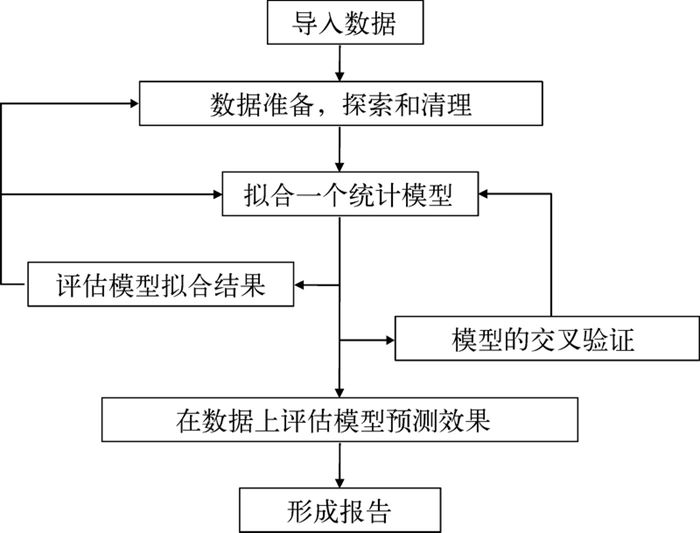

数据分析流程

1. 获取数据（从各种数据源将数据导入程序）
2. 整理数据（编码缺失值、修复或删除错误数据、将变量转换成更方便的格式）
3. 注释数据（以记住每段数据的含义）
4. 总结数据（通过描述性统计量了解数据的概况）
5. 数据可视化（一图胜千言）
6. 数据建模（解释数据间的关系，检验假设）
7. 整理结果（创建具有出版水平的表格和图形）

## 4.2 R语言基础

### 4.2.1 R语言的特点

R是一种**区分大小写**的解释型语言。

### 4.2.2 R中命令的执行

R语言中命令的执行方法有两种：

- 你可以在命令提示符（> ）后每次输入并执行一条命令（一次性的）

```r
# 控制台运行：Enter键
```

- 或者一次性执行写在脚本文件中的一组命令（可反复执行、调试）

```r
# 脚本运行（选中后）：Ctrl+Enter键
```

R语言中的注释：

- 由符号 `#` 开头，在 `#` 之后出现的任何文本都会被R解释器忽略

```r
# 多行注释（选中后）：Ctrl+Shift+C
```

R语句由函数和赋值构成:

- R的赋值符号：`<-`（快捷键：alt+-）

```r
x <- rnorm(5)
```

### 4.2.3 R的数据类型与R对象

#### 1.数值类型

数值是某些变量的组成部分；但有些变量也无法由数值组成，比如字符串。

- 计算数值

```r
100^0.5#指数
log(2)#自然对数
exp(1)#自然对数的底
6.22e23#科学计数
abs(-10)#取绝对值
```

- 特殊数值

```r
# NA（缺失值）
# Inf（无穷大）
```

#### 2.变量类型

不同类型的变量组成数据，变量是数据结构的基本单元。

```r
# integer（整数）
# numeric（实数）
# character（字符）
# logical（逻辑值）
```

#### 3.数据类型

不同数据形式可以组成R对象，但R对象不一定只能由数据构成（图像等也行）；应当说，R对象是R语言中一切被赋值的对象的统称，这其中当然包括使用数据赋值的对象。

R中有多种数据类型，包括向量、矩阵、数据框（与数据集类似）以及列表（各种对象的集合），它们都由变量（连续变量、离散变量、称名变量）构成。

```r
# vector
# factor
# matrix
# data.frame
```

#### 4.R对象

R各种的数据类型组成R对象的其中一部分，但R的数据类型不等于R对象本身——R对象和R的数据类型呈现出类似交集的关系。

**R对象**可以是任何能被赋值的东西；对于R来说，对象可以是任何东西（数据、函数、图形、分析结果，等等）。

- 每一个R对象都有一个类属性，类属性可以告诉R怎么对之进行处理。
- R对象与Environment：一次交互式会话期间的所有数据对象都被保存在内存中；不会因为关闭文件而需要重新将R对象跑出来。

#### 5.涉及数据的基本运算符

```r
# <-
# 赋值符号x <- 23

# &；|；!
# 逻辑运算符：与；或；非

# $
# 列表索引

# ==；>；>=；!=
# 关系运算符：等于；大于；大于等于；不等于
```

#### 6.查看数据类型

```r
class(x)#查看数据类型
```

```
## [1] "numeric"
```

#### 7.（强制）转化数据类型

```r
as.factor(x)#强制转化
```

```
## [1] 1.12378460756568  -0.93368399418267 0.646948416324088 0.277232545687059
## [5] 1.2318201686096
## 5 Levels: -0.93368399418267 0.277232545687059 ... 1.2318201686096
```

### 4.2.4 数据的基本操作

注：这里的数据基础操作不是指对数据进行初步的描述性统计，而是一些对数据进行概览的简单命令。

#### 1.数据查看

```r
iris #显示所有数据
head(iris) #查看表头
tail(iris,2) #表尾
names(iris) #变量名
dim(iris) #行数+列数
class(iris) #数据类型
length(iris) #数据表列数，向量元素数
str(iris)
#查看数据表结构
summary(iris)
#查看数据表概要
```

#### 2.数据处理

主要的包是dplyr包：https://cran.r-project.org/web/packages/dplyr/vignettes/dplyr.html

```r
mutate() #基于现有变量添加新变量
select() #选特定列
filter() #根据值选择
summarise() #将多个值汇总
```

#### 3.数据可视化

[与ggplot2 包相关的109 种拓展包](https://exts.ggplot2.tidyverse.org/gallery/)

[R graph gallery(提供可视化图+代码，便于复现和学习)](https://r-graph-gallery.com/index.html)

#### 4.数据连续操作

管道符 %>%

```r
starwars %>%   #管道符，传递作用 Ctrl + Shift + M
  group_by(species) %>%    #分组
  summarise(n = n(), mass = mean(mass, na.rm = TRUE)) %>% #计算
  filter( n > 1, mass > 50)  #筛选
#基于种（species）
#计算每个种有多少个n()以及计算每个species重量的均值（mean(mass)）
#筛选个数> 1，重量均值> 50
#返回species，符合条件的n及mass
```

### 4.2.5 工作空间（Work Flow）

- 工作空间就是当前R的工作环境，它存储着所有用户定义的对象（向量、矩阵、函数、数据框、列表）。在一个R会话结束时，你可以将当前工作空间保存到一个镜像中，并在下次启动R时自动载入它。查看已输入命令的历史记录，这样我们就可以选择一个之前输入过的命令并适当修改，最后按回车重新执行它。
- 当前的工作目录是R用来读取文件和保存结果的默认目录。我们可以使用函数getwd() 来查看当前的工作目录，或使用函数setwd() 设定当前的工作目录。
- 如果需要读入一个不在当前工作目录下的文件，则需在调用语句中写明**完整的路径**。记得使用引号闭合这些目录名和文件名。

常见的命令如下表：

| 函数 | 功能 |
| --- | --- |
| getwd() | 显示当前的工作目录 |
| setwd(” *mydirectory* “) | 修改当前的工作目录为 *`mydirectory`* |
| ls() | 列出当前工作空间中的对象 |
| rm( *objectlist* ) | 移除（删除）一个或多个对象 |
| help( *options* ) | 显示可用选项的说明 |
| options() | 显示或设置当前选项 |
| history( *#* ) | 显示最近使用过的 # 个命令（默认值为25） |
| savehistory(” *myfile* “) | 保存命令历史到文件 *`myfile`* 中（默认值为.Rhistory） |
| loadhistory(” *myfile* “) | 载入一个**命令历史**文件（默认值为.Rhistory） |
| save.image(” *myfile* “) | 保存工作空间到文件 *`myfile`* 中（默认值为.RData） |
| save(*objectlist* , file=” *myfile* “) | 保存指定对象到一个文件中 |
| load(” *myfile* “) | 读取一个**工作空间**到当前会话中（默认值为.RData） |
| q() | 退出R。将会询问你是否保存工作空间 |

以下是代码操作流程：

#### 1.设置工作目录

```r
setwd("F:/R-File/Project")
```

#### 2.浏览工作环境设置并调整

使用`options`命令将当前的选项设置情况将显示出来；

使用`option(digits=3)`可以使得数字格式化，显示为具有小数点后三位有效数字的格式。

- 注：如果使用Rstudio这样的IDE，这一步是可以基于可视化界面设置的，那样也直观

```r
options()
options(digits=3)
```

#### 3.读取和查看数据

在示例中，接下来，创建了一个包含20个均匀分布随机变量的向量，生成了此数据的摘要统计量和直方图。

```r
x <- runif(20)
summary(x)
```

```
##    Min. 1st Qu.  Median    Mean 3rd Qu.    Max.
## 0.06443 0.32521 0.44960 0.49468 0.68823 0.85228
```

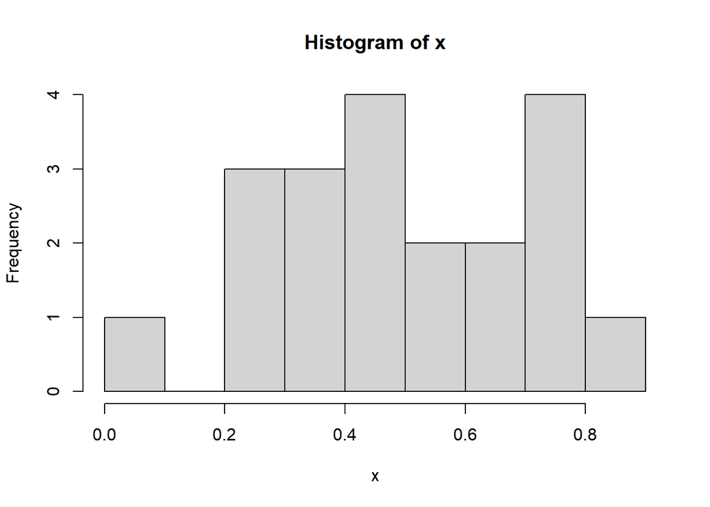

```r
hist(x)
```

```r
library(ggplot2)
```

#### 4.导出与退出R

当q() 函数被运行的时候，程序将向用户询问是否保存工作空间。如果用户输入y，命令的**历史记录（History）**保存到文件.Rhistory中，**工作空间（Environment）**保存到当前目录中的文件.RData中，会话结束，R程序退出。

```r
ggsave()
dev.off()
q()
```

注意：

在R中，所有涉及需要输入路径的命令，都和其他变成语言有所差异，下面以setwd()为例进行说明：

1. setwd()命令的路径中必须使用正斜杠。R将反斜杠（/）作为一个转义符。即使你在Windows平台上运行R，在路径中也要使用正斜杠（`/`）,或者使用双反斜杠（`\\`）也行。
2. 同时注意，函数setwd()不会自动创建一个不存在的目录。如果必要的话，可以新建文件夹目录，然后使用setwd()将工作目录指向这个新目录。

### 4.2.6 R包的使用注意事项

包是R函数、数据、预编译代码以一种定义完善的格式组成的集合：

1. 包在计算机上的存储位置：计算机上存储包的目录称为库 （library）
2. 函数.libPaths()能够显示库所在的位置， 函数library()则可以显示库中有哪些包。

```r
.libPaths()
```

```
## [1] "F:/R/R-4.4.3/library"
```

```r
library()
```

#### 1.R包的下载与更新

```r
# install.packages()
# 不加参数执行命令install.packages()将显示一个CRAN镜像站点的列表，选择其中一个镜像站点之后，将看到所有可用包的列表，选择其中的一个包即可进行下载和安装。
# install.packages("gclus")
# 将包名作为参数提供给这个函数
```

```r
update.packages()# 更新已经安装的包
installed.packages()# 列出安装的包，以及它们的版本号、依赖关系等信息
```

#### 2.R包的调用

要在R会话中使用包，需要使用library()命令载入这个包。一些基本函数是默认直接可用的，而其他高级函数则包含于按需加载的程序包中。

```r
library(gclus)
```

#### 3.R（包）的帮助文档

1. 预览R包可以绘制的图

若想大致了解R能够作出何种图形，在命令行中运行demo()即可；类似的命令还有demo(Hershey) 、demo(persp) 和demo(image)。

要看到完整的演示列表，不加参数直接运行demo()即可。

```r
demo()
```

2. R包的帮助文档

包中往往提供了演示性的小型数据集和示例代码，能够让我们尝试这些新功能。帮助系统包含了每个函数的一个描述（同时带有示例），每个数据集的信息也被包括其中。

```r
help(package="package_name")
# 输出某个包的简短描述以及包中的函数名称和数据集名称的列表
help()
# 查看包中任意函数或数据集的更多细节
```

## 4.3 R语言的注意事项

### 4.3.1 存储路径的表示

在windows系统中，存储路径是反斜线`\`，但这个在R中表示，就需要两个反斜线`\\`或者一个正斜线`/`；比方说：

windows：`D:\Drivers\Audio\Source\0ExtRtk_IntcOED_Yx70QSWHQL`

上面这个在R中表达为：

`D:\\Drivers\\Audio\Source\\0ExtRtk_IntcOED_Yx70QSWHQL`或者`D:/Drivers/Audio/Source/0ExtRtk_IntcOED_Yx70QSWHQL`

### 4.3.2 运算符的优先级问题

R中的运算符有许多，优先级也差的不少，所以不确定优先级的时候使用括号，括号的优先级永远最大。

### 4.3.3 R中大小写会有影响吗

在R中，相同拼写的命令，因为大小写不一样，其意思可能会差的很多。

### 4.3.4 R中如何查看细节代码

按住Ctrl键点击脚本中出现的任何一个R对象，即可打开这个对象的详细界面。

对于函数，打开的就是函数封装的代码细节；对于一个数据框对象，打开的就是数据框的表格内容。

```r
mtcars#按住Ctrl键并点击mtcars对象进行尝试
```